# 高通量数据分析

王宁宁  
广州医科大学统计学系

## 基因测序的意义

> - **诊断疾病**
> - **治疗疾病**
> - **族谱识别**
> - 其他

## DNA测序技术简史

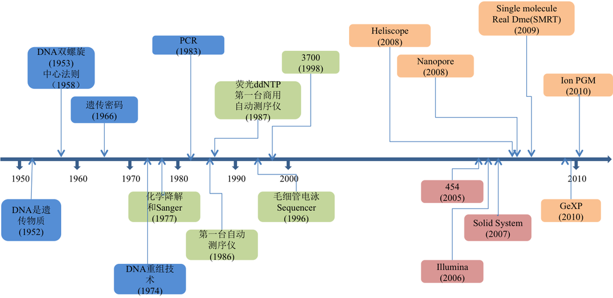

## 什么是高通量测序技术？

> 高通量测序技术（High-throughput sequencing）又称“下一代”测序技术（”Next-generation” sequencing technology），以能一次并行对几十万到几百万条DNA分子进行序列测定和一般读长较短等为标志。

## 高通量测序的标志性技术

- **454焦磷酸测序（454 pyrosequencing）**
- **ABI公司的 SOLiD 技术**
- **Illumina 公司的 Solexa 技术**

## Illumina 公司简介

> Illumina是美国的一家生物科技公司，成立于1998年，总部设于加利福尼亚州圣地亚哥。它在巴西、英国、荷兰、中国、新加坡、日本、澳大利亚也设有分部。其员工超过3000人，2013年总收入达14.2亿。该公司专注于生物信息分析，提供有关SNP基因分型、拷贝数变异（CNV）、基因组测序、DNA甲基化研究、转录组分析、基因表达谱分析相关的服务。如今的Illumina已经占有了基因组测序领域70%的市场份额，在2014年还被《MIT技术评论》选为年度50家最聪明公司第一位。

## Illumina/Solexa 测序技术

> - 测序过程是以 DNA 单链为模板，在生成互补链时，利用带荧光标记的 dNTP 发出不同颜色的荧光来确定不同的碱基.
> - 新加入的 dNTP 的末端被可逆的保护基团封闭，既保证单次反应只能加入一个碱基，又能在该碱基读取完毕后，将保护基团除去，使得下一个反应可继续进行.
> - Illumina/Solexa 测序平台不断升级，相继推出了 GA（Genome Analyzer）、GA IIx、HiSeq 2000 等测序仪.

## Bioconductor 简介

> [Bioconductor](http://bioconductor.org/) provides tools for the analysis and comprehension of high-throughput genomic data.
- Bioconductor uses the R statistical programming language, and is open source and open development.
- It has two releases each year, 1024 software packages, and an active user community.

## 高通量数据分析的准备工作

- R 3.1 以上版本
- 安装[Rtools](http://cran.r-project.org/bin/windows/Rtools/)
- 安装包[devtools](http://cran.r-project.org/web/packages/devtools/index.html)
- 使用devtools 安装github上的包：

```
library(devtools)
install_github("rafalib","ririzarr","genomicsclass/GSE5859Subset")
```

- 使用biocLite安装Bionconductor的包:

```
source("http://www.bioconductor.org/biocLite.R")
biocLite("genefilter")
```

> [这里](https://github.com/genomicsclass/windows)有一个上述安装的教程

## 实例

> 对24个人的血液样本的8793 个基因的测序

```
library(GSE5859Subset)
data(GSE5859Subset)
```

sampleInfo:

```
> dim(sampleInfo)
[1] 24  4
> head(sampleInfo)
    ethnicity       date         filename group
107       ASN 2005-06-23 GSM136508.CEL.gz     1
122       ASN 2005-06-27 GSM136530.CEL.gz     1
113       ASN 2005-06-27 GSM136517.CEL.gz     1
163       ASN 2005-10-28 GSM136576.CEL.gz     1
153       ASN 2005-10-07 GSM136566.CEL.gz     1
161       ASN 2005-10-07 GSM136574.CEL.gz     1
```

geneAnnotation:

```
> dim(geneAnnotation)
[1] 8793    4
> head(geneAnnotation)
     PROBEID  CHR     CHRLOC SYMBOL
1  1007_s_at chr6   30852327   DDR1
30   1053_at chr7  -73645832   RFC2
31    117_at chr1  161494036  HSPA6
32    121_at chr2 -113973574   PAX8
33 1255_g_at chr6   42123144 GUCA1A
34   1294_at chr3  -49842638   UBA7
```

geneExpression:

```
> dim(geneExpression)
[1] 8793   24
```

```
>match(sampleInfo$filename,colnames(geneExpression))
 [1]  1  2  3  4  5  6  7  8  9 10 11 12 13 14 15 16 17 18 19
[20] 20 21 22 23 24
>head(match(geneAnnotation$PROBEID,rownames(geneExpression)))
[1] 1 2 3 4 5 6
```

根据上面的数据集试回答下列问题：

1. Y 染色体的基因有多少个？
2. 基因ARPC1A在2005-06-10的基因表达是多少？

> 答案：

```
sum(geneAnnotation$CHR=="chrY",na.rm=TRUE)

i = which(geneAnnotation$SYMBOL=="ARPC1A")
j = which(sampleInfo$date=="2005-06-10")
geneExpression[i,j]
```

## 高通量数据分析的目的

- **Inference**: for which genes are the population averages different across ethnic groups?
- **Machine learning**: build an algorithm that given gene expression patterns, predicts ethnic group.
- **Clustering**: Can we discover subpopulations of individuals from the gene expression patterns? Or can we discover genes pathways based on which cluster together across individuals?
- **Exploratory data analysis**: Did some experiments failed experiments? Are the assumptions needed to use standard statistical techniques met?

## 初步分析

```
library(GSE5859Subset)
data(GSE5859Subset)
g <- sampleInfo$groupg
```

> **问题**：两组样本里哪些基因的基因表达有差异？（t检验）

[output not shown]

```stata
t.test(e[g==1],e[g==0])
```

```
##
##  Welch Two Sample t-test
##
## data:  e[g == 1] and e[g == 0]
## t = 0.2838, df = 21.217, p-value = 0.7793
## alternative hypothesis: true difference in means is not equal to 0
## 95 percent confidence interval:
##  -0.1431452  0.1884244
## sample estimates:
## mean of x mean of y
##  10.52505  10.50241
```

> 这只是对第25个基因的检验，需要对所有8793个基因做t检验：

```
myttest <- function(x) t.test(x[g==1],x[g==0],var.equal=TRUE)$p.value
pvals <- apply(geneExpression,1,myttest)
sum(pvals<0.05)
## [1] 1383
```

> **答案**：在0.05的显著水平下，有大概1383个基因表达在两组样本所来自的母体之间有差异。

**注意** 对于高通量数据的t检验，这并不是有效的方法，下面是有效的方法之一：

```
library(genefilter)
results <- rowttests(geneExpression,factor(g))
max(abs(pvals-results$p))
## [1] 6.528111e-14
```

> 结果表明两者没有差别。

> **如何看待这个结论呢？**下面是一个统计模拟实验：

```stata
set.seed(1)
m <- nrow(geneExpression)
n <- ncol(geneExpression)
randomData <- matrix(rnorm(n*m),m,n)
nullpvals <- apply(randomData,1,myttest)
sum(nullpvals<0.05)
## [1] 419
```

> **解释**：即使所有数据来自同一总体（标准正态分布），做8793次t检验也会有419次是有差异的。

**练习** 假定原假设为真，考虑样本容量为12的两样本t检验：

1. 按照0.05的检验水平，考虑8793次t检验中，至少有一次错误拒绝原假设的概率是多少？
2. 如果要把上述错误概率减小到0.05，需要把检验水平调整到多少？

## The Concept of a Error Controlling Procedure

在进行多重假设检验时，每个单独的假设都具有其本身的I型错误。在这种情况下，如果不进行任何的控制，犯I-型错误的概率会随着假设检验的个数而迅速增加。

### 错误发现率（FDR : False discovery rate）

[output not shown]

**参考文献**：

- Irizarry R, et al. (2015) Biomedical Data Science. Course Notes, EdX PH525.1x.
- Hahne F, Huber W, Gentleman R, et al. Bioconductor case studies[M]. Springer Science & Business Media, 2010.
- Gentleman R, Carey V, Huber W, et al. Bioinformatics and computational biology solutions using R and Bioconductor[M]. Springer Science & Business Media, 2006.
- 王兴春, 杨致荣, 王敏, 等. 高通量测序技术及其应用[J]. 中国生物工程杂志, 2012, 32(1): 109-114.
- 吴一龙. 高通量测序技术在肺癌研究中的应用[J]. 肿瘤研究与临床, 2014 (2): 133-135.